# Microbial Compositional Analysis in Colorectal Cancer vs. Normal Colon Tissue

Now, let’s take a look at the ASVs. This is where the *real* biology happens! ASV-level plots provide a more detailed view of **which specific taxa are driving the overall trends seen at higher taxonomic levels** between CRC and Normal colon samples.

Before calculating ASV-level abundances, we remove ASVs that have an overall count below 1% of the scaled sample depth across the entire dataset. This dramatically reduces the number of ASVs and makes ASV-level data analysis much easier. Of course, differential abundance testing would be the ideal approach to rigorously identify which ASVs differ significantly between groups — but here we focus on exploratory visualization first.

```r
# Calculate the ASV relative abundance
# Prune out ASVs that have fewer than ~1% of the scaled read depth
ASV_df <-
  scaled_physeq %>%
  prune_taxa(taxa_sums(.) >= (0.01 * min(sample_sums(scaled_physeq))), .) %>%
  tax_glom(taxrank = "ASV") %>%
  transform_sample_counts(function (x) {x/sum(x)}) %>%
  psmelt()

# Make a list of the top 15 ASVs in the dataset
top15_ASVs <-
  ASV_df %>%
  group_by(ASV) %>%
  summarize(mean_PercAbund = mean(Abundance)) %>%
  arrange(-mean_PercAbund) %>%
  head(n = 15) %>%
  pull(ASV)

# Show it
top15_ASVs
```

```
##  [1] "ASV_0001" "ASV_0003" "ASV_0002" "ASV_0004" "ASV_0006" "ASV_0007"
##  [7] "ASV_0010" "ASV_0012" "ASV_0008" "ASV_0013" "ASV_0005" "ASV_0023"
## [13] "ASV_0019" "ASV_0015" "ASV_0021"
```

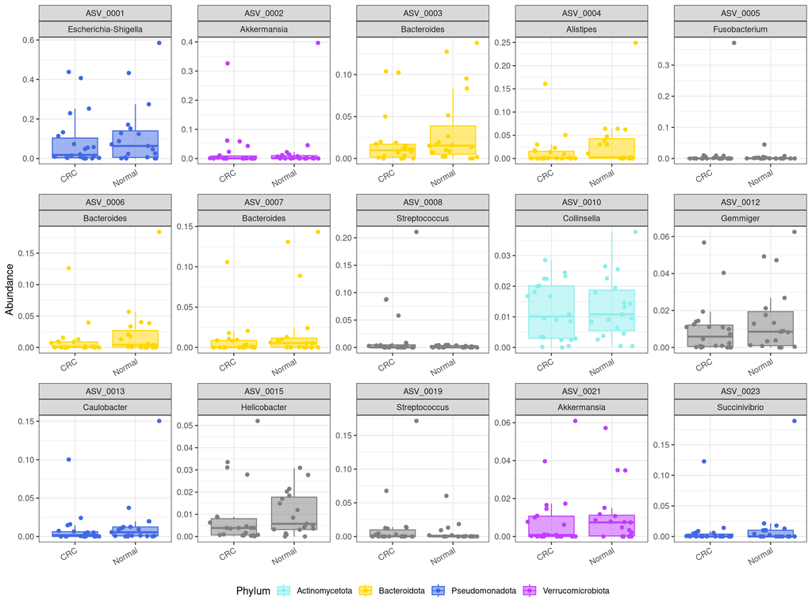

```r
### Plot the Top 15 ASVs
ASV_df %>%
  dplyr::filter(ASV %in% top15_ASVs) %>%
  ggplot(aes(x = ethnicity, y = Abundance, fill = Phylum, color = Phylum)) +
  facet_wrap(ASV~Genus, scales = "free", nrow = 3) +
  geom_jitter() +
  geom_boxplot(outlier.shape = NA, alpha = 0.5) +
  scale_fill_manual(values = phylum_colors) +
  scale_color_manual(values = phylum_colors) +
  theme_bw() +
  theme(legend.position = "bottom",
        axis.text.x = element_text(angle = 30, hjust = 1, vjust = 1),
        axis.title.x = element_blank())
```

# B. Within Phylum-Level

Here we narrow in on specific phyla that appear to vary between CRC and Normal samples based on the overview plots above. For each phylum, we plot relative abundance by CRC status (categorical).

## B1. Firmicutes (Bacillota)

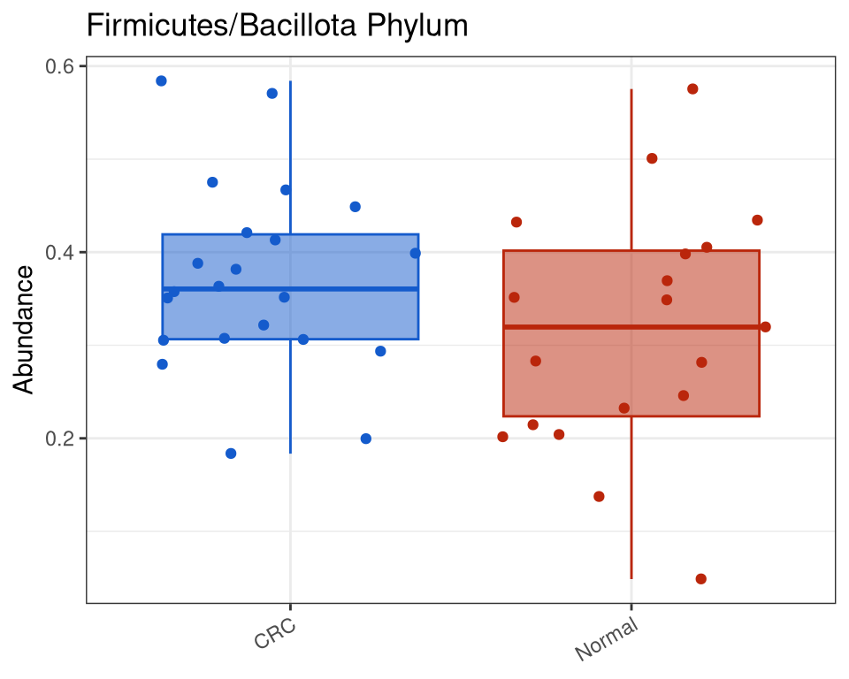

```r
# Firmicutes/Bacillota abundance by CRC status
firmicutes_phylum_crcGroup <-
  phylum_df %>%
  dplyr::filter(Phylum == "Firmicutes" | Phylum == "Bacillota") %>%
  ggplot(aes(x = ethnicity, y = Abundance,
             fill = ethnicity, color = ethnicity)) +
  geom_boxplot(alpha = 0.5, outlier.shape = NA) +
  geom_jitter() +
  theme_bw() +
  labs(title = "Firmicutes/Bacillota Phylum") +
  scale_color_manual(values = crc_colors) +
  scale_fill_manual(values = crc_colors) +
  theme(axis.text.x = element_text(angle = 30, hjust = 1, vjust = 1),
        legend.position = "none",
        axis.title.x = element_blank())

firmicutes_phylum_crcGroup
```

## B2. Bacteroidota

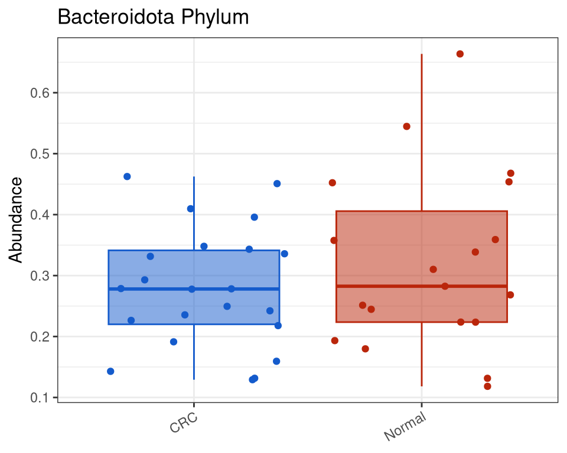

```r
# Bacteroidota abundance by CRC status
bacteroidota_phylum_crcGroup <-
  phylum_df %>%
  dplyr::filter(Phylum == "Bacteroidota") %>%
  ggplot(aes(x = ethnicity, y = Abundance,
             fill = ethnicity, color = ethnicity)) +
  geom_boxplot(alpha = 0.5, outlier.shape = NA) +
  geom_jitter() +
  theme_bw() +
  labs(title = "Bacteroidota Phylum") +
  scale_color_manual(values = crc_colors) +
  scale_fill_manual(values = crc_colors) +
  theme(axis.text.x = element_text(angle = 30, hjust = 1, vjust = 1),
        legend.position = "none",
        axis.title.x = element_blank())

bacteroidota_phylum_crcGroup
```

## B3. Proteobacteria (Pseudomonadota)

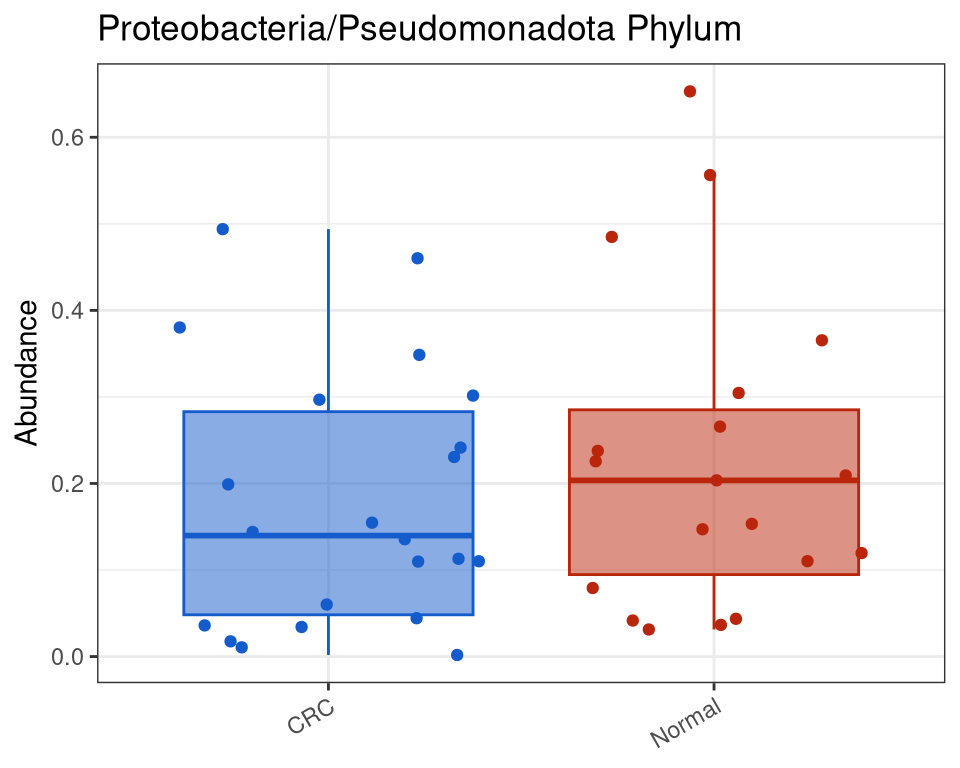

```r
# Proteobacteria/Pseudomonadota abundance by CRC status
proteo_phylum_crcGroup <-
  phylum_df %>%
  dplyr::filter(Phylum == "Proteobacteria" | Phylum == "Pseudomonadota") %>%
  ggplot(aes(x = ethnicity, y = Abundance,
             fill = ethnicity, color = ethnicity)) +
  geom_boxplot(alpha = 0.5, outlier.shape = NA) +
  geom_jitter() +
  theme_bw() +
  labs(title = "Proteobacteria/Pseudomonadota Phylum") +
  scale_color_manual(values = crc_colors) +
  scale_fill_manual(values = crc_colors) +
  theme(axis.text.x = element_text(angle = 30, hjust = 1, vjust = 1),
        legend.position = "none",
        axis.title.x = element_blank())

proteo_phylum_crcGroup
```

## B4. Fusobacteriota

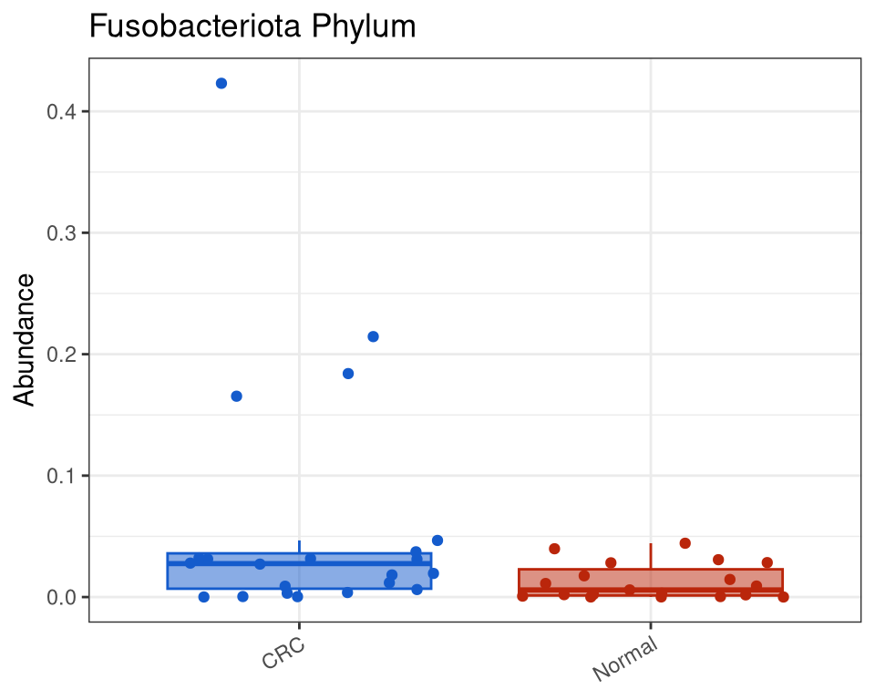

```r
# Fusobacteriota abundance by CRC status
# Note: Fusobacterium nucleatum is one of the most well-documented CRC-associated bacteria
fuso_phylum_crcGroup <-
  phylum_df %>%
  dplyr::filter(Phylum == "Fusobacteriota" | Phylum == "Fusobacteria") %>%
  ggplot(aes(x = ethnicity, y = Abundance,
             fill = ethnicity, color = ethnicity)) +
  geom_boxplot(alpha = 0.5, outlier.shape = NA) +
  geom_jitter() +
  theme_bw() +
  labs(title = "Fusobacteriota Phylum") +
  scale_color_manual(values = crc_colors) +
  scale_fill_manual(values = crc_colors) +
  theme(axis.text.x = element_text(angle = 30, hjust = 1, vjust = 1),
        legend.position = "none",
        axis.title.x = element_blank())

fuso_phylum_crcGroup
```

## Phylum Summary Plot

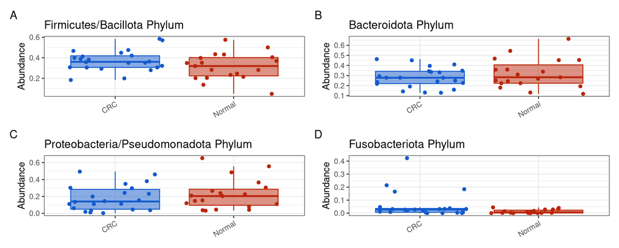

```r
# Put the key phyla together for comparison
firmicutes_phylum_crcGroup + bacteroidota_phylum_crcGroup +
proteo_phylum_crcGroup + fuso_phylum_crcGroup +
  plot_layout(guides = "collect") +
  plot_annotation(tag_levels = "A")
```

INTERPRETATION #4: Based on these phylum-level analyses, were there any phyla that showed notable differences between CRC and Normal samples? Which phyla will you focus on for deeper taxonomic analyses? Why?

# C. Genus-Level

Let’s first calculate the genus data frame, then focus on genera within the phyla that showed the most interesting CRC-associated patterns above.

```r
# Calculate the genus relative abundance
genus_df <-
  scaled_physeq %>%
  tax_glom(taxrank = "Genus") %>%
  transform_sample_counts(function (x) {x/sum(x)}) %>%
  psmelt()
```

## C1. Firmicutes Genera

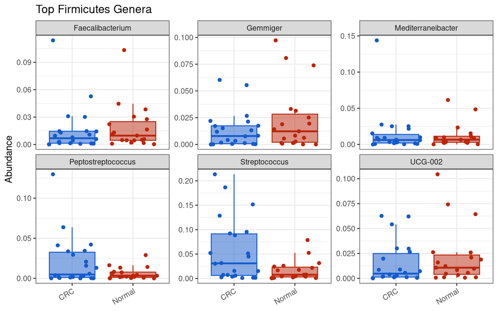

```r
# Identify the top Firmicutes genera
top_firmicutes_genera <-
  genus_df %>%
  dplyr::filter(Phylum == "Firmicutes" | Phylum == "Bacillota") %>%
  group_by(Genus) %>%
  summarize(mean_Abundance = mean(Abundance)) %>%
  arrange(-mean_Abundance) %>%
  head(n = 6) %>%
  pull(Genus)

# Plot genus by CRC status
firmicutes_genus_crcGroup <-
  genus_df %>%
  dplyr::filter(Phylum == "Firmicutes" | Phylum == "Bacillota") %>%
  dplyr::filter(Genus %in% top_firmicutes_genera) %>%
  ggplot(aes(x = ethnicity, y = Abundance,
             fill = ethnicity, color = ethnicity)) +
  facet_wrap(.~Genus, scales = "free_y", nrow = 2) +
  geom_boxplot(alpha = 0.5, outlier.shape = NA) +
  geom_jitter() +
  theme_bw() +
  labs(title = "Top Firmicutes Genera") +
  scale_color_manual(values = crc_colors) +
  scale_fill_manual(values = crc_colors) +
  theme(axis.text.x = element_text(angle = 30, hjust = 1, vjust = 1),
        legend.position = "none",
        axis.title.x = element_blank())

firmicutes_genus_crcGroup
```

## C2. Fusobacteriota Genera

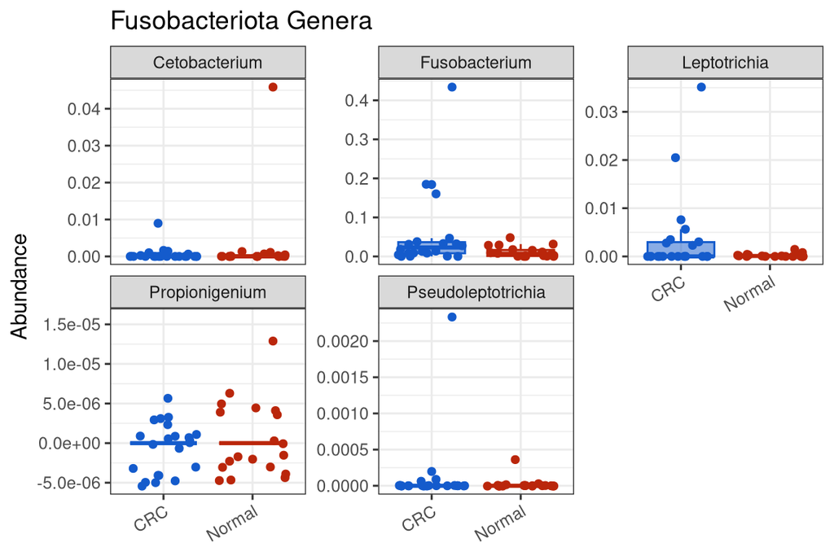

```r
# Fusobacterium is among the most well-documented CRC-associated genera
# Fusobacterium nucleatum has been shown to promote tumor growth and invasion
fuso_genus_crcGroup <-
  genus_df %>%
  dplyr::filter(Phylum == "Fusobacteriota" | Phylum == "Fusobacteria") %>%
  ggplot(aes(x = ethnicity, y = Abundance,
             fill = ethnicity, color = ethnicity)) +
  facet_wrap(.~Genus, scales = "free_y") +
  geom_boxplot(alpha = 0.5, outlier.shape = NA) +
  geom_jitter() +
  theme_bw() +
  labs(title = "Fusobacteriota Genera") +
  scale_color_manual(values = crc_colors) +
  scale_fill_manual(values = crc_colors) +
  theme(axis.text.x = element_text(angle = 30, hjust = 1, vjust = 1),
        legend.position = "none",
        axis.title.x = element_blank())

fuso_genus_crcGroup
```

## C3. Bacteroidota Genera

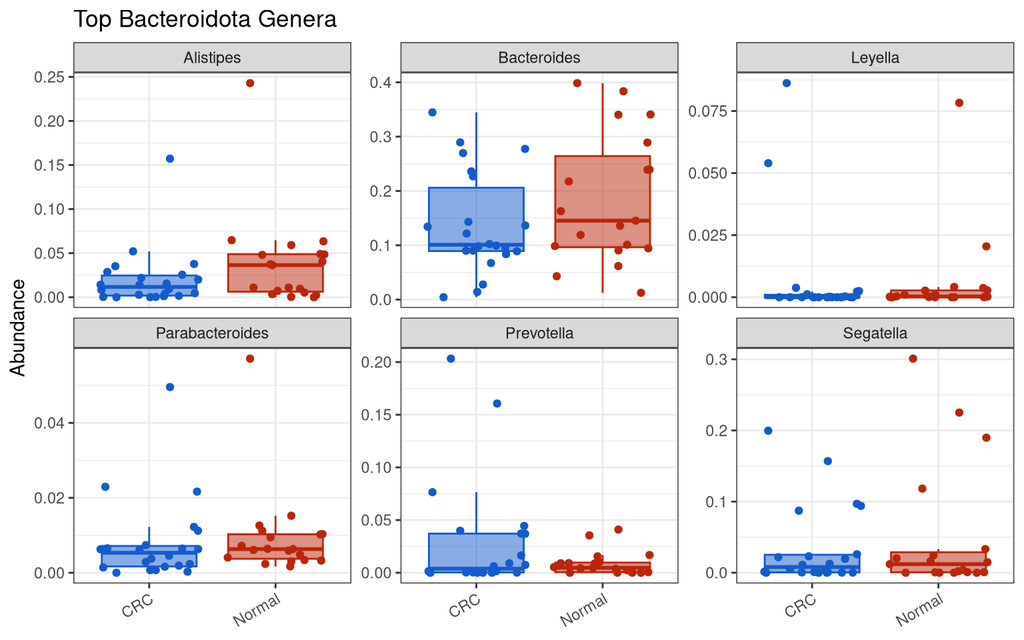

```r
# Identify the top Bacteroidota genera
top_bacteroidota_genera <-
  genus_df %>%
  dplyr::filter(Phylum == "Bacteroidota") %>%
  group_by(Genus) %>%
  summarize(mean_Abundance = mean(Abundance)) %>%
  arrange(-mean_Abundance) %>%
  head(n = 6) %>%
  pull(Genus)

# Plot genus by CRC status
bacteroidota_genus_crcGroup <-
  genus_df %>%
  dplyr::filter(Phylum == "Bacteroidota") %>%
  dplyr::filter(Genus %in% top_bacteroidota_genera) %>%
  ggplot(aes(x = ethnicity, y = Abundance,
             fill = ethnicity, color = ethnicity)) +
  facet_wrap(.~Genus, scales = "free_y", nrow = 2) +
  geom_boxplot(alpha = 0.5, outlier.shape = NA) +
  geom_jitter() +
  theme_bw() +
  labs(title = "Top Bacteroidota Genera") +
  scale_color_manual(values = crc_colors) +
  scale_fill_manual(values = crc_colors) +
  theme(axis.text.x = element_text(angle = 30, hjust = 1, vjust = 1),
        legend.position = "none",
        axis.title.x = element_blank())

bacteroidota_genus_crcGroup
```

INTERPRETATION #5: Make some plots of mid-level taxonomic ranks (e.g. Genus, Family, Order) as they relate to CRC vs. Normal status. Were there any changes in the mid-level taxonomic trends compared to the phylum-level results? What does that tell you about that taxonomic group?

The genus-level plots reveal considerably more biological resolution than the phylum-level analysis. Within Bacillota, the phylum-level signal clearly disaggregates into taxa with opposing trends — Streptococcus and Peptostreptococcus appear markedly enriched in CRC samples (Streptococcus reaching ~20% in some individuals), while Faecalibacterium and Gemmiger trend higher in Normal samples. This divergence explains why the Bacillota phylum-level signal was ambiguous: the phylum contains both CRC-enriched pathobionts and CRC-depleted commensals whose opposing signals cancel each other out at broader taxonomic resolution. Within Fusobacteriota, Fusobacterium itself shows the most compelling CRC-associated pattern in the entire dataset — several CRC samples reach ~20–40% relative abundance while Normal samples remain consistently near zero, representing the canonical CRC microbiome signal documented extensively in the literature. Within Bacteroidota, no genus shows a strong or consistent between-group difference, confirming that this phylum does not harbor a meaningful CRC-associated signal in this dataset and will be deprioritized for ASV-level follow-up in favor of Fusobacteriota and the CRC-enriched Firmicutes genera.

# D. ASV-Level

Here we zoom in to the ASV level for the phyla and genera that showed the most interesting CRC-associated patterns above. ASV-level analysis allows us to determine whether phylum-level trends are driven by a single dominant taxon or by consistent patterns across multiple ASVs.

## D1. Fusobacteriota ASVs

Fusobacterium nucleatum is one of the most well-documented bacteria in colorectal cancer research. Here we examine whether specific Fusobacteriota ASVs are enriched in CRC vs. Normal samples.

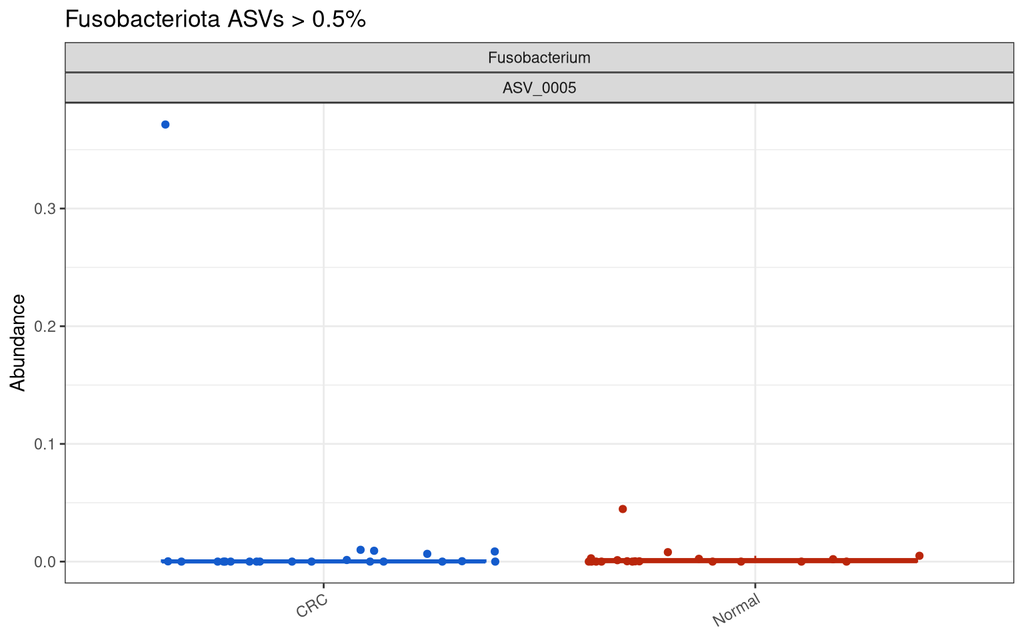

```r
# Get Fusobacteriota ASVs above 0.5% mean abundance
top_fuso_ASVs <-
  ASV_df %>%
  dplyr::filter(Phylum == "Fusobacteriota" | Phylum == "Fusobacteria") %>%
  group_by(ASV) %>%
  summarize(mean_Abundance = mean(Abundance)) %>%
  dplyr::filter(mean_Abundance > 0.005) %>%
  pull(ASV)

# Plot ASVs by CRC status
fuso_asv_crcGroup <-
  ASV_df %>%
  dplyr::filter(ASV %in% top_fuso_ASVs) %>%
  ggplot(aes(x = ethnicity, y = Abundance,
             fill = ethnicity, color = ethnicity)) +
  facet_wrap(Genus~ASV, scales = "free_y", nrow = 2) +
  geom_boxplot(alpha = 0.5, outlier.shape = NA) +
  geom_jitter() +
  theme_bw() +
  labs(title = "Fusobacteriota ASVs > 0.5%") +
  scale_color_manual(values = crc_colors) +
  scale_fill_manual(values = crc_colors) +
  theme(axis.text.x = element_text(angle = 30, hjust = 1, vjust = 1),
        legend.position = "none",
        axis.title.x = element_blank())

fuso_asv_crcGroup
```

## D2. Firmicutes ASVs

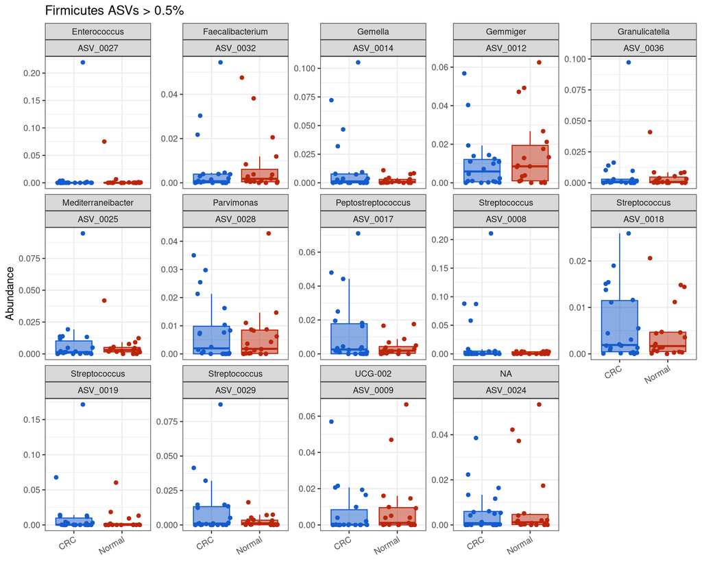

```r
# Get top Firmicutes ASVs above 0.5% mean abundance
top_firmicutes_ASVs <-
  ASV_df %>%
  dplyr::filter(Phylum == "Firmicutes" | Phylum == "Bacillota") %>%
  group_by(ASV) %>%
  summarize(mean_Abundance = mean(Abundance)) %>%
  dplyr::filter(mean_Abundance > 0.005) %>%
  pull(ASV)

# Plot ASVs by CRC status
firmicutes_asv_crcGroup <-
  ASV_df %>%
  dplyr::filter(ASV %in% top_firmicutes_ASVs) %>%
  ggplot(aes(x = ethnicity, y = Abundance,
             fill = ethnicity, color = ethnicity)) +
  facet_wrap(Genus~ASV, scales = "free_y", nrow = 3) +
  geom_boxplot(alpha = 0.5, outlier.shape = NA) +
  geom_jitter() +
  theme_bw() +
  labs(title = "Firmicutes ASVs > 0.5%") +
  scale_color_manual(values = crc_colors) +
  scale_fill_manual(values = crc_colors) +
  theme(axis.text.x = element_text(angle = 30, hjust = 1, vjust = 1),
        legend.position = "none",
        axis.title.x = element_blank())

firmicutes_asv_crcGroup
```

## D3. Bacteroidota ASVs

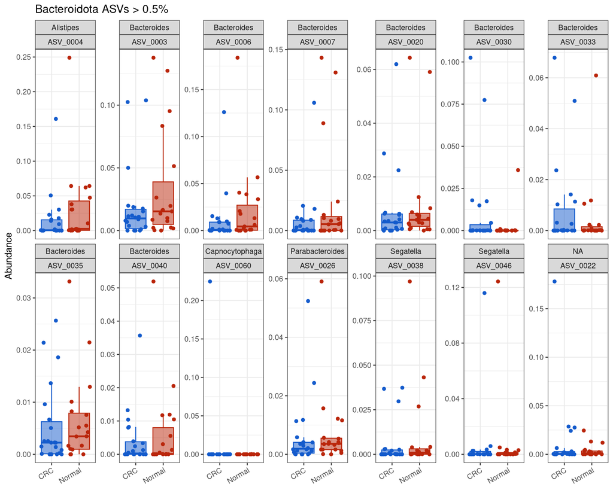

```r
# Get top Bacteroidota ASVs above 0.5% mean abundance
top_bacter_ASVs <-
  ASV_df %>%
  dplyr::filter(Phylum == "Bacteroidota") %>%
  group_by(ASV) %>%
  summarize(mean_Abundance = mean(Abundance)) %>%
  dplyr::filter(mean_Abundance > 0.005) %>%
  pull(ASV)

# Plot ASVs by CRC status
bacter_asv_crcGroup <-
  ASV_df %>%
  dplyr::filter(ASV %in% top_bacter_ASVs) %>%
  ggplot(aes(x = ethnicity, y = Abundance,
             fill = ethnicity, color = ethnicity)) +
  facet_wrap(Genus~ASV, scales = "free_y", nrow = 2) +
  geom_boxplot(alpha = 0.5, outlier.shape = NA) +
  geom_jitter() +
  theme_bw() +
  labs(title = "Bacteroidota ASVs > 0.5%") +
  scale_color_manual(values = crc_colors) +
  scale_fill_manual(values = crc_colors) +
  theme(axis.text.x = element_text(angle = 30, hjust = 1, vjust = 1),
        legend.position = "none",
        axis.title.x = element_blank())

bacter_asv_crcGroup
```

INTERPRETATION #6: Were the most abundant ASVs in your dataset represented in your ASV-level plots? If not, please go back and plot them specifically. (Hint: Remember that we ordered our ASV names by abundance across the entire dataset. Therefore, ASV_0001 will be the most abundant, ASV_0007 will be the 7th most abundant and so on.)

The most abundant ASVs in the dataset (ASV_0001 through ASV_0010) are not all represented in these phylum-specific ASV plots, which is expected — the top ASVs by overall abundance span multiple phyla, and our phylum-specific plots only show ASVs within Fusobacteriota, Firmicutes, and Bacteroidota that exceed the 0.5% mean abundance threshold. Notably, ASV_0005 is the only Fusobacteriota ASV above this threshold and is assigned to Fusobacterium, confirming it as the primary driver of the Fusobacteriota CRC signal observed at the genus and phylum levels — with one CRC sample reaching ~36% relative abundance while Normal samples remain near zero. Within Firmicutes, the highest-ranked ASVs include ASV_0008 and ASV_0018 (Streptococcus), ASV_0017 (Peptostreptococcus), and ASV_0012 (Gemmiger), with the Streptococcus ASVs showing clear CRC enrichment and Gemmiger trending higher in Normal samples. Within Bacteroidota, multiple Bacteroides ASVs (ASV_0003, ASV_0006, ASV_0007, ASV_0020) dominate the panel with no consistent directional signal between groups, reinforcing the phylum- and genus-level conclusion that Bacteroidota does not show a strong CRC-specific pattern in this dataset. The most abundant ASVs not captured in these plots (likely ASV_0001 and ASV_0002) should be identified by phylum assignment and plotted separately if they belong to a biologically relevant group.

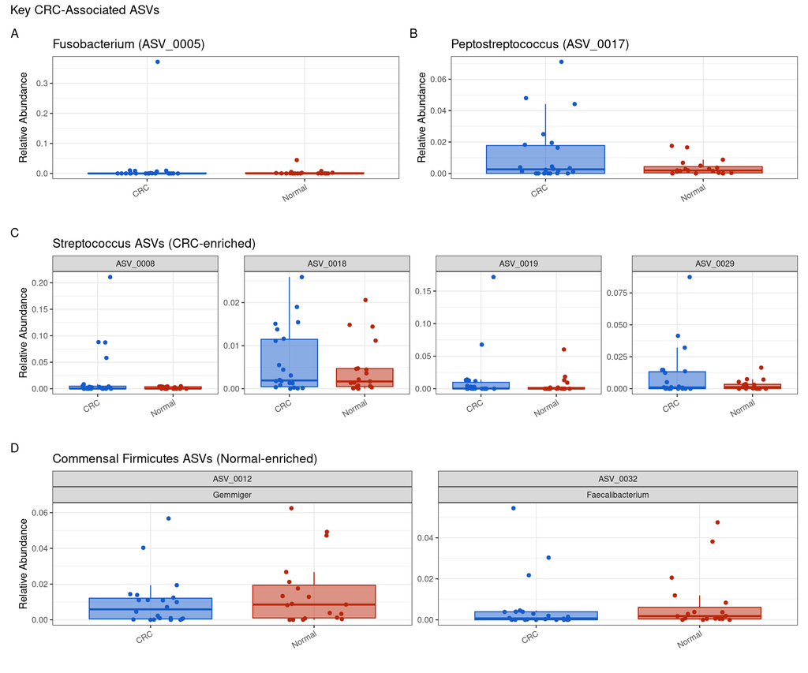

```r
# ── 1. Fusobacterium ASV_0005 — the canonical CRC-associated ASV ──────────────
fuso_asv_plot <-
  ASV_df %>%
  dplyr::filter(ASV == "ASV_0005") %>%
  ggplot(aes(x = ethnicity, y = Abundance,
             fill = ethnicity, color = ethnicity)) +
  geom_boxplot(alpha = 0.5, outlier.shape = NA) +
  geom_jitter(width = 0.2) +
  scale_color_manual(values = crc_colors) +
  scale_fill_manual(values = crc_colors) +
  labs(title = "Fusobacterium (ASV_0005)",
       y = "Relative Abundance", x = "") +
  theme_bw() +
  theme(legend.position = "none",
        axis.text.x = element_text(angle = 30, hjust = 1, vjust = 1))

# ── 2. CRC-enriched Streptococcus ASVs ────────────────────────────────────────
strep_asv_plot <-
  ASV_df %>%
  dplyr::filter(ASV %in% c("ASV_0008", "ASV_0018", "ASV_0019", "ASV_0029")) %>%
  ggplot(aes(x = ethnicity, y = Abundance,
             fill = ethnicity, color = ethnicity)) +
  facet_wrap(~ASV, scales = "free_y", nrow = 1) +
  geom_boxplot(alpha = 0.5, outlier.shape = NA) +
  geom_jitter(width = 0.2) +
  scale_color_manual(values = crc_colors) +
  scale_fill_manual(values = crc_colors) +
  labs(title = "Streptococcus ASVs (CRC-enriched)",
       y = "Relative Abundance", x = "") +
  theme_bw() +
  theme(legend.position = "none",
        axis.text.x = element_text(angle = 30, hjust = 1, vjust = 1))

# ── 3. CRC-enriched Peptostreptococcus ASV ────────────────────────────────────
peptostep_asv_plot <-
  ASV_df %>%
  dplyr::filter(ASV == "ASV_0017") %>%
  ggplot(aes(x = ethnicity, y = Abundance,
             fill = ethnicity, color = ethnicity)) +
  geom_boxplot(alpha = 0.5, outlier.shape = NA) +
  geom_jitter(width = 0.2) +
  scale_color_manual(values = crc_colors) +
  scale_fill_manual(values = crc_colors) +
  labs(title = "Peptostreptococcus (ASV_0017)",
       y = "Relative Abundance", x = "") +
  theme_bw() +
  theme(legend.position = "none",
        axis.text.x = element_text(angle = 30, hjust = 1, vjust = 1))

# ── 4. Normal-enriched commensal Firmicutes ASVs ──────────────────────────────
# Faecalibacterium and Gemmiger — butyrate producers depleted in CRC
commensals_asv_plot <-
  ASV_df %>%
  dplyr::filter(ASV %in% c("ASV_0032", "ASV_0012")) %>%
  ggplot(aes(x = ethnicity, y = Abundance,
             fill = ethnicity, color = ethnicity)) +
  facet_wrap(~ASV + Genus, scales = "free_y", nrow = 1) +
  geom_boxplot(alpha = 0.5, outlier.shape = NA) +
  geom_jitter(width = 0.2) +
  scale_color_manual(values = crc_colors) +
  scale_fill_manual(values = crc_colors) +
  labs(title = "Commensal Firmicutes ASVs (Normal-enriched)",
       y = "Relative Abundance", x = "") +
  theme_bw() +
  theme(legend.position = "none",
        axis.text.x = element_text(angle = 30, hjust = 1, vjust = 1))

# ── 5. Combine all plots ──────────────────────────────────────────────────────
(fuso_asv_plot | peptostep_asv_plot) /
  strep_asv_plot /
  commensals_asv_plot +
  plot_annotation(
    title = "Key CRC-Associated ASVs",
    tag_levels = "A")
```

INTERPRETATION #7: Please make some plots at the ASV level as it relates to your scientific question. Were there any ASVs that were especially related to trends that you saw? Did a specific phylogenetic group all show the same trends? Or did the ASVs have various, likely niche-specific responses?

The ASV-level plots reveal a clear and biologically coherent story that is fully consistent with the known CRC microbiome literature. The CRC-enriched pathobionts and Normal-enriched commensals tell opposing but complementary sides of the same story — gut dysbiosis in CRC involves both a gain of harmful taxa and a loss of protective ones. Fusobacterium (ASV_0005, Panel A) shows the most striking CRC-specific signal in the entire dataset — one CRC sample reaches ~36% relative abundance while the vast majority of Normal samples remain at near-zero. This extreme, sparse enrichment pattern is characteristic of Fusobacterium nucleatum, which is known to colonize tumor tissue in a highly focal and patient-specific manner rather than being universally elevated across all CRC patients. Peptostreptococcus (ASV_0017, Panel B) shows a clear CRC enrichment with several high-abundance outliers in CRC samples and consistently low abundance in Normal samples. Peptostreptococcus species have been associated with CRC in multiple studies and are thought to contribute to tumor microenvironment inflammation. Streptococcus ASVs (Panel C) — unlike the single-taxon Fusobacterium signal — show that the Streptococcus CRC enrichment pattern is consistent across multiple ASVs (ASV_0008, ASV_0018, ASV_0019, ASV_0029), all of which trend higher in CRC samples. This suggests a group-level rather than niche-specific response, where multiple Streptococcus taxa are collectively enriched in the CRC gut environment, possibly reflecting shared ecological traits such as tolerance of the acidic, inflamed tumor microenvironment. Commensal Firmicutes ASVs (Panel D) tell the complementary story — both Gemmiger (ASV_0012) and Faecalibacterium (ASV_0032) trend higher in Normal samples, consistent with their well-established roles as butyrate-producing commensals that support colonocyte health and anti-inflammatory immune tone. Their depletion in CRC samples, while subtle at the ASV level, reinforces the phylum- and genus-level signal and is consistent with the broader literature on the loss of protective Firmicutes in colorectal cancer.

INTERPRETATION #8: Do a quick literature search and look back at the MAL2 paper or related CRC microbiome studies. Does your ASV-level analysis represent something that is currently known in the CRC microbiome literature? Or is this a novel result? What did you learn about this ASV or group of ASVs?